# Labwork 3. Hypothesis Testing. Analysis of Variance

Dovydas Klimas E1863

# 1. Goodness-of-fit distributional testing

### TASK: Apply Goodness-of-fit tests to check whether the sample X follows some specific distribution.

- Import data from Moodle, file lab3_set1.csv.
- Your data set - the **n** column from imported file, where n - is the last digit of your student’s vidko (if 0, then 10th column)

```r
library(dplyr)

library(goftest)

library(ggpubr)

library(QRM)

library(rstatix)





# vidko = E1863
# data import
data <- read.csv('lab3_set1.csv')
data <- data[, c(3)]
```

## 1.1 Testing for Normal distribution

(2 points)

- Draw histogram of imported data sample and add the curve of normal distribution density dnorm().
- Determine mean and standard deviation.
- Set significance level alpha=0.05
- Testing for normality:  
  – if vidko 1-5, then apply Anderson-Darling Test (goftest::ad.test), Shapiro-Wilk Test (shapiro.test) and Pearson’s Chi-squared Test (chisq.test).  
  – if vidko 6-0, then apply Kolmogorov-Smirnov Test (ks.test), Shapiro-Wilk Test (shapiro.test) and Pearson’s Chi-squared Test (chisq.test)
- Answer the questions below.

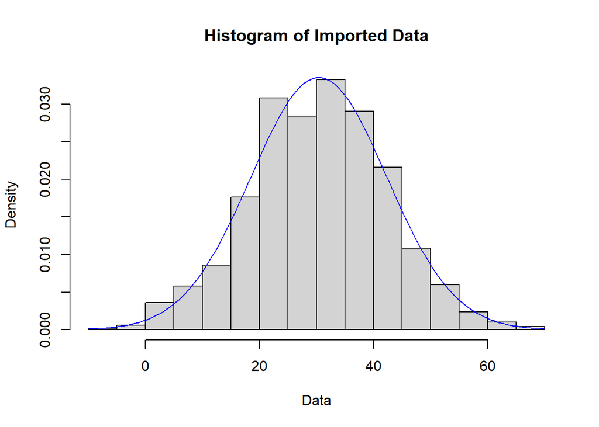

```r
# ad.test requires data to be standardized

hist(
  data, main = "Histogram of Imported Data", xlab = "Data", ylab = "Density", freq = FALSE, plot = TRUE
)
curve(
  dnorm(x, mean = mean(data), sd = sd(data)), add = TRUE, col ="blue"
)
```

```r
cat("Mean of the data:", mean(data), "\n")
```

```
## Mean of the data: 30.403
```

```r
cat("Standard deviation of the data:", sd(data), "\n")
```

```
## Standard deviation of the data: 11.89554
```

```r
alpha <- 0.05
s_data <- scale(data, center=TRUE, scale=TRUE)
ad.test(s_data, "pnorm", mean=mean(s_data), sd=sd(s_data))
```

```
##
##  Anderson-Darling test of goodness-of-fit
##  Null hypothesis: Normal distribution
##  with parameters mean = 3.85689744031303e-17, sd = 1
##  Parameters assumed to be fixed
##
## data:  s_data
## An = 0.23996, p-value = 0.9754
```

```r
shapiro.test(s_data)
```

```
##
##  Shapiro-Wilk normality test
##
## data:  s_data
## W = 0.99893, p-value = 0.8375
```

```r
intervals <- hist(data, plot = FALSE)
cat("bins:", length(intervals$breaks), "\n")
```

```
## bins: 17
```

```r
breaks_cdf <- pnorm(intervals$breaks, mean=mean(data), sd=sd(data))
null.probs <- zoo::rollapply(breaks_cdf, 2, function(x) x[2]-x[1])
chisq.test(intervals$counts, p=null.probs, rescale.p=TRUE, simulate.p.value = TRUE)
```

```
##
##  Chi-squared test for given probabilities with simulated p-value (based
##  on 2000 replicates)
##
## data:  intervals$counts
## X-squared = 14.721, df = NA, p-value = 0.4698
```

```r
qchisq(alpha,length(intervals$breaks)-2-1,lower.tail=FALSE)
```

```
## [1] 23.68479
```

## 1.2 Testing for other than Normal distribution

(1 point)

Assume that data could be described using Student’s t distribution.  
- apply one any goodness-of-fit test to to test whether sample X can be described using Student’s t distribution.  
- repeat the same steps following task 1.1.  
- - p.s. add curve of Student’s t distribution dt() instead of normal distribution. - Answer the questions below.

```r
# for Student's t you will need degrees of freedom (dof):  params<-QRM::fit.st(data); dof<-params$par.ests[["nu"]]


params<-QRM::fit.st(data)
dof<-params$par.ests[["nu"]]
cat("Degrees of freedom: ", round(dof), "\n")
```

```
## Degrees of freedom:  6815
```

```r
ad.test(s_data, "pt", df = dof)
```

```
##
##  Anderson-Darling test of goodness-of-fit
##  Null hypothesis: Student's t distribution
##  with parameter df = 6815.35233773363
##  Parameters assumed to be fixed
##
## data:  s_data
## An = 0.23997, p-value = 0.9754
```

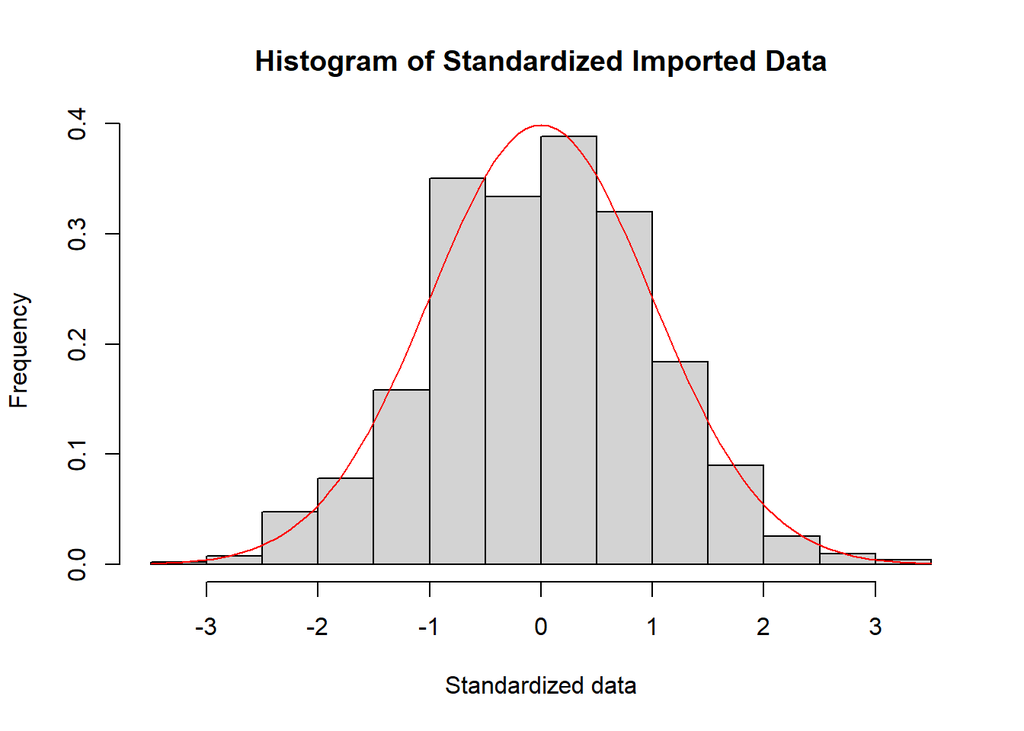

```r
hist(
  s_data, main = "Histogram of Standardized Imported Data", xlab = "Standardized data", ylab = "Frequency", freq = FALSE, plot = TRUE
)
curve(
  dt(x, df = dof), add = TRUE, col = "red"
)
```

```r
ad.test(s_data, "pt", df = 3)
```

```
##
##  Anderson-Darling test of goodness-of-fit
##  Null hypothesis: Student's t distribution
##  with parameter df = 3
##  Parameters assumed to be fixed
##
## data:  s_data
## An = 10.031, p-value = 7.01e-06
```

# 2. Parametric hypothesis about normal distribution parameters

We assume that X - our population, and we create other smaller samples (e.g. Y, Z) of size 100 observations randomly selected from X

```r
set.seed(4200)
Y <- data[sample(length(data), 0.1*length(data))]
set.seed(1234)
Z <- data[sample(length(data), 0.1*length(data))]
```

# 2.1 Parametric hypothesis about Y normal distribution parameter - mean $\mu$, when variance $\sigma^2$ is unknown

(1 point)

- Perform two.tailed test and one one.tailed test following the theory slides about Normal distribution parameter $\mu$ when $\sigma^2$ is not known for data sample $Y$.  
  – assume that $\mu_0$ is the mean of $X$ (status quo). – for this purpose implement the procedure by yourself and then use built-in function t.test  
  – Also, you can follow the examples from http://www.r-tutor.com/elementary-statistics/hypothesis-testing
- Answer the questions below.

```r
# two-tailed test with my own procedure
mu0<-mean(data) # hypothesized value
ybar <- mean(Y)  # sample mean
s <- sd(Y) # population standard deviation
n <- length(Y) # sample size
t = (ybar - mu0)/(s/sqrt(n))  # test statistic
cat("test statistic of two-tailed test: ", t, "\n")
```

```
## test statistic of two-tailed test:  -0.7382953
```

```r
alpha = 0.05
t.half.alpha = qt(1-alpha / 2, df=n-1)
intervals = c(-t.half.alpha, t.half.alpha)
cat("intervals of two-tailed test: ", intervals, "\n")
```

```
## intervals of two-tailed test:  -1.984217 1.984217
```

```r
# two-tailed test with built-in function t.test
t.test(Y , mu = mu0, alternative = "two.sided")
```

```
##
##  One Sample t-test
##
## data:  Y
## t = -0.7383, df = 99, p-value = 0.4621
## alternative hypothesis: true mean is not equal to 30.403
## 95 percent confidence interval:
##  26.95972 31.97876
## sample estimates:
## mean of x
##  29.46924
```

```r
# lower-tailed test with my own procedure
cat("Same t for lower-tailed: ", t, "\n")
```

```
## Same t for lower-tailed:  -0.7382953
```

```r
t.alpha = qt(1-alpha, df=n-1)
cat("-t.alpha of lower-tailed:", -t.alpha, "\n")
```

```
## -t.alpha of lower-tailed: -1.660391
```

```r
# lower-tailed test with built-in function t.test
t.test(Y , mu = mu0, alternative = "less")
```

```
##
##  One Sample t-test
##
## data:  Y
## t = -0.7383, df = 99, p-value = 0.231
## alternative hypothesis: true mean is less than 30.403
## 95 percent confidence interval:
##      -Inf 31.56921
## sample estimates:
## mean of x
##  29.46924
```

Formulate hypothesis for two.tailed test.  
- H0: μ is equal to μ0  
- Ha: μ is not equal to μ0  
- Conclusion from your procedure with explanation why: we follow the null hypothesis because the test statistic of variable ‘t’ lies between the critical values of two-tailed intervals  
- Conclusion from built-in function with explanation why: We follow the null hypothesis because μ is equal to μ0.  
Formulate hypothesis for one one.tailed test.  
- H0: μ is larger or equal to μ0  
- Ha: μ is less than μ0  
- Conclusion from your procedure with explanation why: We follow the null hypothesis because the test statistic of variable ‘t’ is larger than the value of -t.alpha  
- Conclusion from built-in function with explanation why: We follow the null hypothesis because calculated sample mean is similar compared to the theoretical mean and satisfies the “equal” part of the null hypothesis. P-value is larger than the given 0.05

# 2.2 Parametric hypothesis about the equality of two means from different samples $Y$ and $Z$, when variances are unknown

(1 point)

- Perform two.tailed test and one one.tailed test to compare means of two different samples $Y$ and $Z$ based on statistical data
- For this purpose it is recommended to use built-in function t.test and follow the theory. Carefully choose the parameters of used function.
- Answer the questions below.

```r
mean(Y)
```

```
## [1] 29.46924
```

```r
mean(Z)
```

```
## [1] 28.88893
```

```r
sd(Y)
```

```
## [1] 12.64741
```

```r
sd(Z)
```

```
## [1] 11.83407
```

```r
# two-tailed test
t.test(Y, Z, mu = mu0, alternative=c("two.sided"))
```

```
##
##  Welch Two Sample t-test
##
## data:  Y and Z
## t = -17.218, df = 197.13, p-value < 2.2e-16
## alternative hypothesis: true difference in means is not equal to 30.403
## 95 percent confidence interval:
##  -2.835425  3.996054
## sample estimates:
## mean of x mean of y
##  29.46924  28.88893
```

```r
# lower-tailed test
t.test(Y, Z, mu = mu0, alternative=c("less"))
```

```
##
##  Welch Two Sample t-test
##
## data:  Y and Z
## t = -17.218, df = 197.13, p-value < 2.2e-16
## alternative hypothesis: true difference in means is less than 30.403
## 95 percent confidence interval:
##      -Inf 3.442746
## sample estimates:
## mean of x mean of y
##  29.46924  28.88893
```

# 3. One-way ANOVA: task

- You are given a data sample about the posts published in the social network. Sample includes the main variable “likes” and two additional variables: post’s topic, video indicator (duration or no video) and comment to some question.
- The goal – **to determine the existence of a statistically significant difference among the means of “likes” conditioned by two factors “topic” or “video”**. Method - **ANOVA analysis**. All steps and tasks are given below.

You can follow the theory slides of the examples here: https://www.datanovia.com/en/lessons/anova-in-r/ or http://www.sthda.com/english/wiki/one-way-anova-test-in-r#what-is-one-way-anova-test or http://www.sthda.com/english/wiki/kruskal-wallis-test-in-r#multiple-pairwise-comparison-between-groups

# 3.1 Import data

(0.5 point)

- The data are sampled from the file “lab3_set2.csv” found in the Moodle. For this purpose ‘sample’ function is used to randomly select 90% data from the imported data set. Use set.seed() as parameter to control random number generation every time you generate them.
- Verify data types with function str(). ‘topic’and ’video’ should be factors, ‘likes’- numeric (integer).
- Answer the questions below.

```r
data2 <- read.csv2("lab3_set2.csv")
set.seed(2845);
sample <- data2[sample(nrow(data2),0.9*nrow(data2)),]

if (is.numeric(sample$likes))
{
  cat("Variable 'likes' is numeric\n")
} else
    cat("Error: variable 'likes' is not numeric\n")
```

```
## Variable 'likes' is numeric
```

```r
if (is.character(sample$video) && is.character(sample$topic))
{
  cat("Variables 'video', 'topic' are factors\n\n")
} else
    cat("Error: one of the variables ('video', 'topic') are not factors\n\n")
```

```
## Variables 'video', 'topic' are factors
```

- How many factors you have in the sample? 2 - ‘topic’ and ‘video’.  
- How many levels each factor has? Factor topic has 3 levels and factor video has 4 levels  
- What is the dependent (response) variable? likes

# 3.2 Describe and visualise your data

(0.5 point)

- To perform one-way ANOVA, as a factor in further analysis, choose “video”.
- Compute the grand mean and standard deviation.
- Compute the mean and standard deviation for each level to compare the effect.
- Visualise your sample with the aim to show how the mean of response variable differs against levels of factor you have in the sample.
- Answer the questions below.

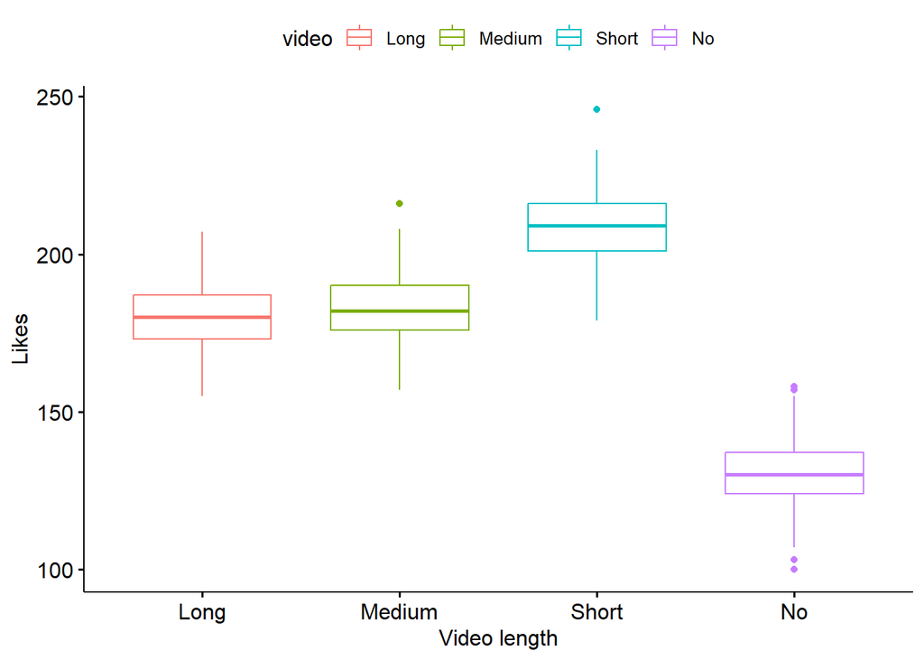

```r
grand_m = mean(sample$likes)
grand_sd = sd(sample$likes)

m_long = mean(sample[sample$video == "Long",]$likes)
m_medium = mean(sample[sample$video == "Medium",]$likes)
m_short = mean(sample[sample$video == "Short",]$likes)
m_no = mean(sample[sample$video == "No",]$likes)
sd_long = sd(sample[sample$video == "Long",]$likes)
sd_medium = sd(sample[sample$video == "Medium",]$likes)
sd_short = sd(sample[sample$video == "Short",]$likes)
sd_no = sd(sample[sample$video == "No",]$likes)

ggboxplot(sample, x = "video", y = "likes", color = "video", order = c("Long", "Medium", "Short", "No"), ylab = "Likes", xlab = "Video length")
```

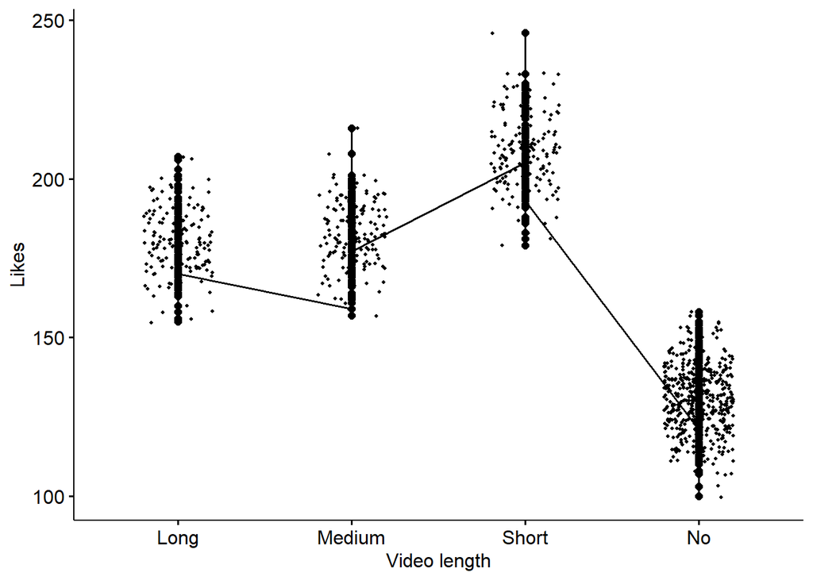

```r
ggline(sample, x = "video", y = "likes", add = c("m_sd", "jitter"), size = 0.7, add.params = list(size = 0.7, alpha = 1), order = c("Long", "Medium", "Short", "No"), ylab = "Likes", xlab = "Video length")
```

- Are the means different? the means between different video lengths are different.  
- Are the difference among means is statistically significant? The means between ‘Long’ and ‘Medium’ video lengths are not statistically significant,As for the ‘No’ and ‘Short’ video lengths, means are statistically significant.

# 3.3 Design one-way ANOVA experiment

(1 point)

# 3.4 Check one-way ANOVA assumptions.

(1 point)

1. Check the homogeneity of variance assumption (Levene’s test).
2. Check the normality assumption (Shapiro-Wilk test).
3. Check for significant outliers (If extreme outliers exist, remove them).

```r
sample %>% levene_test(likes ~ video)
```

| df1 | df2 | statistic | p |
| --- | --- | --- | --- |
| 3 | 896 | 1.626515 | 0.1816434 |

```r
sample %>% group_by(video) %>% shapiro_test(likes)
```

| video | variable | statistic | p |
| --- | --- | --- | --- |
| Long | likes | 0.9923716 | 0.5966613 |
| Medium | likes | 0.9929006 | 0.6536280 |
| No | likes | 0.9972651 | 0.6719452 |
| Short | likes | 0.9928053 | 0.6612352 |

```r
sample %>% group_by(video) %>% identify_outliers(likes)
```

| video | likes | topic | comments | is.outlier | is.extreme |
| --- | --- | --- | --- | --- | --- |
| Medium | 216 | P3 | Disagree | TRUE | FALSE |
| No | 157 | P3 | Neutral | TRUE | FALSE |
| No | 103 | P1 | Neutral | TRUE | FALSE |
| No | 100 | P3 | Agree | TRUE | FALSE |
| No | 158 | P2 | Neutral | TRUE | FALSE |
| Short | 246 | P1 | Agree | TRUE | FALSE |

Give comments about each of test verified.  
1. p-value is larger than the given value of 0.05, therefore there is no significant difference between given groups.  
2. p-values is larger than the given value of 0.05, due to this, we we can assume normality  
3. There are no extreme outliers  
Then, make a final decision what procedure (parametric or non-parametric) will be applied for further analysis.  
Student’s comments: All the assumptions were satisfied and due to this, the parametric procedure will be followed.

# 3.5 Compute one-way ANOVA for ‘video’ factor.

(1 point)

- Perform the analysis of variance for ‘video’ factor.
- Make a conclusion from ANOVA.

```r
sample %>% anova_test(likes ~ video)
```

|  | Effect | DFn | DFd | F | p | p<.05 | ges |
| --- | --- | --- | --- | --- | --- | --- | --- |
| 1 | video | 3 | 896 | 2709.773 | 0 | * | 0.901 |

```r
# res.aov <- aov(target ~ factor, data = my_data) #F-test
# summary(res.aov)
# res.aov <-oneway.test(target ~ factor, data = my_data)  # Welch one-way test could be used instead of classical approach with F test
# kruskal.test(target ~ factor, data = my_data) # Kruskal-Wallis rank sum test could be used instead of classical approach with F test
```

# 3.6 Multiple pairwise-comparison between the means of groups

(1 point)

Decide whether it makes sense to perform multiple pairwise-comparisons for all factors you have in the sample. If yes - perform multiple pairwise-comparisons and make final decision about the differences among groups. If not - just give comments why this step is not relevant.

```r
# TukeyHSD(res.aov)
# pairwise.wilcox.test(variable, factor,  p.adjust.method = "BH")
```